# Practical Machine Learning Course Project

Matthias Busl

September 2015

## Question

The question behind the dataset and course project can be formulated as:

Can a three sensor on body measurement be used to categorize the way an defined exercise (Unilateral Dumbbell Biceps Curl) was made into five classes consisting of the “right way” and four common mistakes?

## Input data and feature extraction

The input data used comes from three sensors from a person doing a certain exercise. The feature extraction already was made in the data (averages etc).

### Treating non-numerical data

However a first look into the data shows missing features for a lot of datasets plus some errors that occured at the level of feature creation (“DIV/0”). So the data was read in and the missing and not correctly calculated values treated as “not available” directly at that stage.

```r
raw_data <- read.table("pml-training.csv", header=TRUE, sep = ",", na.strings=c("", "NA", "#DIV/0!"))
```

Also the first colums only contain data that is only used in order to identfy the dataset (username, timestamp); it contains no information about how the exercise was done and is therefore not selected. Also the “num_window” variable ist one of those identifying only the fact that the same execution class of the exercise was repeated it contains no information on *how* the exercise was done.

A look at the number of not available data for each column shows that there are many rows (actually 100 out of 153) that only values for very few datasets. So instead of estimating missing values the only reasonable way to treat these features is to delete them entirely. After that procedure all “NA”s are gone.

```r
pml_data <- subset(raw_data, select = roll_belt:classe)
columns_to_drop <- which(colSums(is.na(pml_data)) > nrow(pml_data)*0.75)
pml_data <- pml_data[, -columns_to_drop]
```

### Properties of the resulting data

A quick check shows that the resulting data contains no zero or near zero variance predictors.

```r
nzv <- nearZeroVar(pml_data, saveMetrics= TRUE)
sum(nzv$nzv == TRUE)
```

```
## [1] 0
```

So there is no need for removing further colums.

Another check is to find correlating features:

```r
descrCor <- abs(cor(pml_data[,-c(ncol(pml_data))]))
diag(descrCor) <- 0
which(descrCor > 0.95,arr.ind=T)
```

```
##                  row col
## total_accel_belt   4   1
## accel_belt_z      10   1
## accel_belt_x       8   2
## roll_belt          1   4
## accel_belt_z      10   4
## pitch_belt         2   8
## roll_belt          1  10
## total_accel_belt   4  10
## gyros_dumbbell_z  33  31
## gyros_dumbbell_x  31  33
```

### Data splitting

Since there is only one dataset available I chose to split that “training” dataset into a training part for the algorithm and a test set in order to being able to evaluate the out of sample error of an algorithm more realistic. Since computing time and memory was a concern at the first tries with the suggested 60%/40% split, I used only 30% for the training set.

```r
inTrain <- createDataPartition(y=pml_data$classe,
                              p=0.3, list=FALSE)
training <- pml_data[inTrain,]
testing <- pml_data[-inTrain,]
```

This leads to 5889 training and 13733 testing datasets.

With this partition the cross validation is the testing set which is quite large and should therefore give a good estimate for the out of sample error.

## Algorithm

First the importance of the features is evaluated using a simple random forest scan:

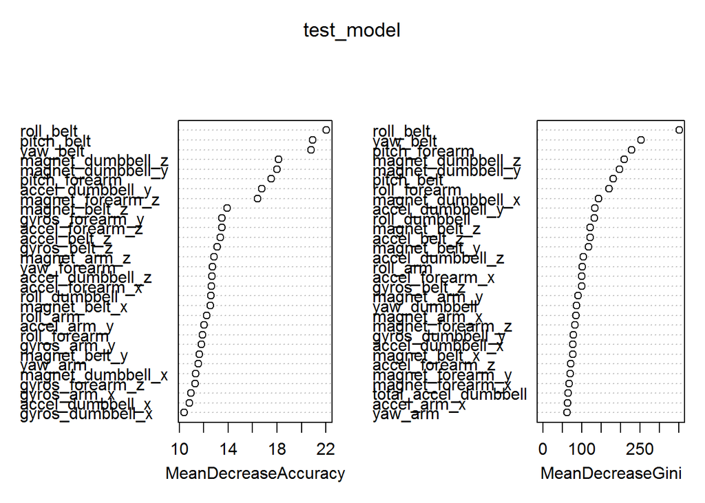

```r
library(randomForest)
test_model <- randomForest(classe~., data=training, importance=TRUE, ntree=100)
varImpPlot(test_model)
```

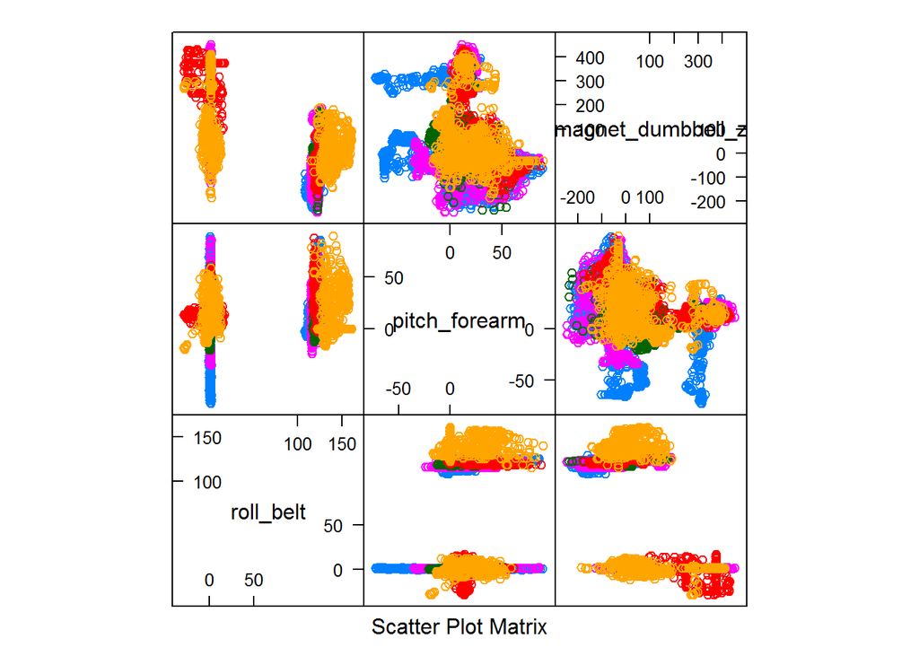

Interestingly a density plot shows mostly gaussian looking distributions (here shown for an example feature).

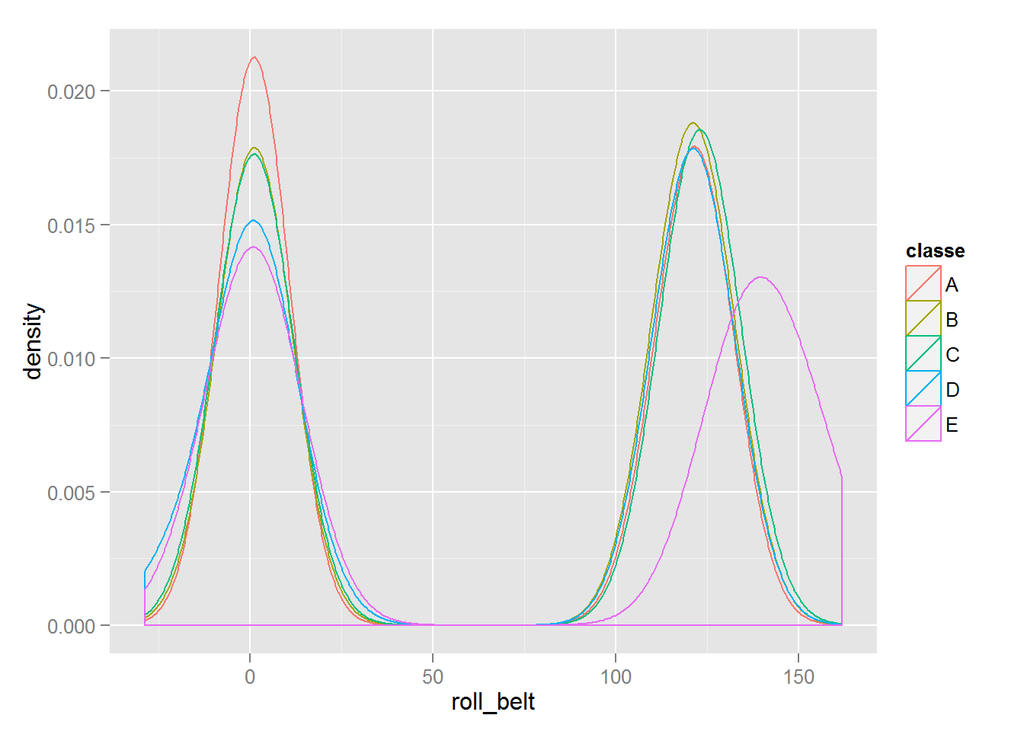

This leads to the selection of three different algorithms that are suitable for nonlinear problems and will be tested:

- Boosting
- Random Forest
- Model based (Naive Bayes)

## Evaluation

Four models are created and tested on the test set in order to geta good estimate for the out of sample error.

### Boosting

```r
gbm_model <- train(classe ~ ., data=training,method="gbm", verbose=FALSE)
```

```r
confusionMatrix(testing$classe,predict(gbm_model,testing))
```

```
## Confusion Matrix and Statistics
##
##           Reference
## Prediction    A    B    C    D    E
##          A 3840   41   21    3    1
##          B  128 2395  108    9   17
##          C    2   69 2284   38    2
##          D    1    8   73 2140   29
##          E    4   24   23   39 2434
##
## Overall Statistics
##
##                Accuracy : 0.9534
##                  95% CI : (0.9497, 0.9569)
##     No Information Rate : 0.2894
##     P-Value [Acc > NIR] : < 2.2e-16
##
##                   Kappa : 0.941
##  Mcnemar's Test P-Value : < 2.2e-16
##
## Statistics by Class:
##
##                      Class: A Class: B Class: C Class: D Class: E
## Sensitivity            0.9660   0.9440   0.9103   0.9601   0.9803
## Specificity            0.9932   0.9766   0.9901   0.9904   0.9920
## Pos Pred Value         0.9831   0.9014   0.9537   0.9507   0.9643
## Neg Pred Value         0.9863   0.9872   0.9802   0.9922   0.9956
## Prevalence             0.2894   0.1847   0.1827   0.1623   0.1808
## Detection Rate         0.2796   0.1744   0.1663   0.1558   0.1772
## Detection Prevalence   0.2844   0.1935   0.1744   0.1639   0.1838
## Balanced Accuracy      0.9796   0.9603   0.9502   0.9752   0.9861
```

This algorithm gives an accuracy of about 95% which is already not bad.

This gives an first estimate for the out of sample error of approximately 5%.

### Naive Bayes

```r
nb_model <- train(classe ~ ., data=training,method="nb", verbose=FALSE)
```

```r
confusionMatrix(testing$classe,predict(nb_model,testing))
```

```
## Confusion Matrix and Statistics
##
##           Reference
## Prediction    A    B    C    D    E
##          A 3389   41  160  254   62
##          B  507 1643  279  161   67
##          C  547  156 1581   93   18
##          D  451    3  289 1398  110
##          E  159  245  112  106 1902
##
## Overall Statistics
##
##                Accuracy : 0.7218
##                  95% CI : (0.7143, 0.7293)
##     No Information Rate : 0.3679
##     P-Value [Acc > NIR] : < 2.2e-16
##
##                   Kappa : 0.6444
##  Mcnemar's Test P-Value : < 2.2e-16
##
## Statistics by Class:
##
##                      Class: A Class: B Class: C Class: D Class: E
## Sensitivity            0.6707   0.7869   0.6530   0.6948   0.8810
## Specificity            0.9404   0.9129   0.9280   0.9272   0.9463
## Pos Pred Value         0.8676   0.6184   0.6601   0.6211   0.7536
## Neg Pred Value         0.8307   0.9598   0.9259   0.9465   0.9771
## Prevalence             0.3679   0.1520   0.1763   0.1465   0.1572
## Detection Rate         0.2468   0.1196   0.1151   0.1018   0.1385
## Detection Prevalence   0.2844   0.1935   0.1744   0.1639   0.1838
## Balanced Accuracy      0.8056   0.8499   0.7905   0.8110   0.9136
```

Even though the data looked gaussian distributed, wich led to the use of this algorithm, the performance is bad, giving only 72 % accuracy. Maybe this is because the data peaks are quite equally centered as seen in the density plot above.

The out of sample error ist therefore estimated to be 28 percent.

### Random forest

As suggested in the lecture cross validation is used.

```r
rf_model<-train(classe ~ .,data=training,method="rf",
                trControl=trainControl(method="cv",number=5),
                allowParallel=TRUE)
```

```r
confusionMatrix(testing$classe,predict(rf_model,testing))
```

```
## Confusion Matrix and Statistics
##
##           Reference
## Prediction    A    B    C    D    E
##          A 3886   16    3    0    1
##          B   56 2563   37    1    0
##          C    0   23 2364    8    0
##          D    0    3   46 2195    7
##          E    0    8   17    5 2494
##
## Overall Statistics
##
##                Accuracy : 0.9832
##                  95% CI : (0.9809, 0.9853)
##     No Information Rate : 0.287
##     P-Value [Acc > NIR] : < 2.2e-16
##
##                   Kappa : 0.9787
##  Mcnemar's Test P-Value : NA
##
## Statistics by Class:
##
##                      Class: A Class: B Class: C Class: D Class: E
## Sensitivity            0.9858   0.9809   0.9582   0.9937   0.9968
## Specificity            0.9980   0.9915   0.9972   0.9951   0.9973
## Pos Pred Value         0.9949   0.9646   0.9871   0.9751   0.9881
## Neg Pred Value         0.9943   0.9955   0.9909   0.9988   0.9993
## Prevalence             0.2870   0.1903   0.1796   0.1609   0.1822
## Detection Rate         0.2830   0.1866   0.1721   0.1598   0.1816
## Detection Prevalence   0.2844   0.1935   0.1744   0.1639   0.1838
## Balanced Accuracy      0.9919   0.9862   0.9777   0.9944   0.9971
```

```r
rf_model_pca<-train(classe ~ .,data=training,method="rf", preProcess="pca",
                trControl=trainControl(method="cv",number=10),
                allowParallel=TRUE)
confusionMatrix(testing$classe,predict(rf_model,testing))
```

```
## Confusion Matrix and Statistics
##
##           Reference
## Prediction    A    B    C    D    E
##          A 3886   16    3    0    1
##          B   56 2563   37    1    0
##          C    0   23 2364    8    0
##          D    0    3   46 2195    7
##          E    0    8   17    5 2494
##
## Overall Statistics
##
##                Accuracy : 0.9832
##                  95% CI : (0.9809, 0.9853)
##     No Information Rate : 0.287
##     P-Value [Acc > NIR] : < 2.2e-16
##
##                   Kappa : 0.9787
##  Mcnemar's Test P-Value : NA
##
## Statistics by Class:
##
##                      Class: A Class: B Class: C Class: D Class: E
## Sensitivity            0.9858   0.9809   0.9582   0.9937   0.9968
## Specificity            0.9980   0.9915   0.9972   0.9951   0.9973
## Pos Pred Value         0.9949   0.9646   0.9871   0.9751   0.9881
## Neg Pred Value         0.9943   0.9955   0.9909   0.9988   0.9993
## Prevalence             0.2870   0.1903   0.1796   0.1609   0.1822
## Detection Rate         0.2830   0.1866   0.1721   0.1598   0.1816
## Detection Prevalence   0.2844   0.1935   0.1744   0.1639   0.1838
## Balanced Accuracy      0.9919   0.9862   0.9777   0.9944   0.9971
```

## Cross validation

### Round 2

```r
set.seed(234)
inTrain <- createDataPartition(y=pml_data$classe,
                              p=0.3, list=FALSE)
training <- pml_data[inTrain,]
testing <- pml_data[-inTrain,]
```

```r
rf_model<-train(classe ~ .,data=training,method="rf",
                trControl=trainControl(method="cv",number=5),
                allowParallel=TRUE)
```

```r
confusionMatrix(testing$classe,predict(rf_model,testing))
```

```
## Confusion Matrix and Statistics
##
##           Reference
## Prediction    A    B    C    D    E
##          A 3897    2    7    0    0
##          B   44 2573   35    0    5
##          C    0   45 2332   16    2
##          D    0    3   47 2198    3
##          E    2    7    7    9 2499
##
## Overall Statistics
##
##                Accuracy : 0.983
##                  95% CI : (0.9807, 0.9851)
##     No Information Rate : 0.2871
##     P-Value [Acc > NIR] : < 2.2e-16
##
##                   Kappa : 0.9784
##  Mcnemar's Test P-Value : NA
##
## Statistics by Class:
##
##                      Class: A Class: B Class: C Class: D Class: E
## Sensitivity            0.9883   0.9783   0.9605   0.9888   0.9960
## Specificity            0.9991   0.9924   0.9944   0.9954   0.9978
## Pos Pred Value         0.9977   0.9684   0.9737   0.9765   0.9901
## Neg Pred Value         0.9953   0.9949   0.9915   0.9978   0.9991
## Prevalence             0.2871   0.1915   0.1768   0.1619   0.1827
## Detection Rate         0.2838   0.1874   0.1698   0.1601   0.1820
## Detection Prevalence   0.2844   0.1935   0.1744   0.1639   0.1838
## Balanced Accuracy      0.9937   0.9854   0.9774   0.9921   0.9969
```

### Round 3

```r
set.seed(456)
inTrain <- createDataPartition(y=pml_data$classe,
                              p=0.3, list=FALSE)
training <- pml_data[inTrain,]
testing <- pml_data[-inTrain,]
```

```r
rf_model<-train(classe ~ .,data=training,method="rf",
                trControl=trainControl(method="cv",number=5),
                allowParallel=TRUE)
```

```r
confusionMatrix(testing$classe,predict(rf_model,testing))
```

```
## Confusion Matrix and Statistics
##
##           Reference
## Prediction    A    B    C    D    E
##          A 3892   12    1    0    1
##          B   77 2559   20    1    0
##          C    0   36 2342   17    0
##          D    0    5   45 2189   12
##          E    1   12    9   15 2487
##
## Overall Statistics
##
##                Accuracy : 0.9808
##                  95% CI : (0.9783, 0.983)
##     No Information Rate : 0.2891
##     P-Value [Acc > NIR] : < 2.2e-16
##
##                   Kappa : 0.9757
##  Mcnemar's Test P-Value : NA
##
## Statistics by Class:
##
##                      Class: A Class: B Class: C Class: D Class: E
## Sensitivity            0.9804   0.9752   0.9690   0.9851   0.9948
## Specificity            0.9986   0.9912   0.9953   0.9946   0.9967
## Pos Pred Value         0.9964   0.9631   0.9779   0.9725   0.9853
## Neg Pred Value         0.9921   0.9941   0.9934   0.9971   0.9988
## Prevalence             0.2891   0.1911   0.1760   0.1618   0.1820
## Detection Rate         0.2834   0.1863   0.1705   0.1594   0.1811
## Detection Prevalence   0.2844   0.1935   0.1744   0.1639   0.1838
## Balanced Accuracy      0.9895   0.9832   0.9821   0.9899   0.9958
```

### Round 4

```r
set.seed(567)
inTrain <- createDataPartition(y=pml_data$classe,
                              p=0.3, list=FALSE)
training <- pml_data[inTrain,]
testing <- pml_data[-inTrain,]
```

```r
rf_model<-train(classe ~ .,data=training,method="rf",
                trControl=trainControl(method="cv",number=5),
                allowParallel=TRUE)
```

```r
confusionMatrix(testing$classe,predict(rf_model,testing))
```

```
## Confusion Matrix and Statistics
##
##           Reference
## Prediction    A    B    C    D    E
##          A 3878   17    8    0    3
##          B   43 2589   17    8    0
##          C    0   27 2341   21    6
##          D    0    1   37 2209    4
##          E    2   13    7   30 2472
##
## Overall Statistics
##
##                Accuracy : 0.9822
##                  95% CI : (0.9799, 0.9844)
##     No Information Rate : 0.2857
##     P-Value [Acc > NIR] : < 2.2e-16
##
##                   Kappa : 0.9775
##  Mcnemar's Test P-Value : NA
##
## Statistics by Class:
##
##                      Class: A Class: B Class: C Class: D Class: E
## Sensitivity            0.9885   0.9781   0.9714   0.9740   0.9948
## Specificity            0.9971   0.9939   0.9952   0.9963   0.9954
## Pos Pred Value         0.9928   0.9744   0.9775   0.9813   0.9794
## Neg Pred Value         0.9954   0.9948   0.9939   0.9949   0.9988
## Prevalence             0.2857   0.1927   0.1755   0.1651   0.1810
## Detection Rate         0.2824   0.1885   0.1705   0.1609   0.1800
## Detection Prevalence   0.2844   0.1935   0.1744   0.1639   0.1838
## Balanced Accuracy      0.9928   0.9860   0.9833   0.9852   0.9951
```

### Conclusion

Since the outcome is nearly the same, the out of sample error is estimated to be 2%.

## Applying to the project test data set

The data is treated in the same manner as the training data.

```r
raw_test_data <- read.table("pml-testing.csv", header=TRUE, sep = ",", na.strings=c("", "NA", "#DIV/0!"))
test_data <- subset(raw_test_data, select = roll_belt:problem_id)
test_data <- test_data[, -columns_to_drop]
```

The algorithms are now applied to the 20 test cases.

```r
predict(gbm_model,test_data)
```

```
##  [1] B A B A A E D B A A B C B A E E A B B B
## Levels: A B C D E
```

```r
predict(nb_model,test_data)
```

```
##  [1] A A A A A E D C A A A A B A E A A B A B
## Levels: A B C D E
```

```r
predict(rf_model,test_data)
```

```
##  [1] B A B A A E D B A A B C B A E E A B B B
## Levels: A B C D E
```

The random forest and boosting predictions are the same and they also show a good accuracy on the out of sample testing set, so their result is submitted.